# R for reproducible scientific analysis

Creating publication quality graphics

## Learning Objectives

> - To be able to use ggplot2 to generate publication quality graphics
> - To understand the basics of the grammar of graphics:
> - The aesthetics layer
> - The geometry layer
> - Adding statistics
> - Transforming scales
> - Coloring or paneling by groups.

Plotting our data is one of the best ways to quickly explore it and the various relationships between variables.

There are three main plotting systems in R, the [base plotting system](http://www.statmethods.net/graphs/), the [lattice](http://www.statmethods.net/advgraphs/trellis.html) package, and the [ggplot2](http://www.statmethods.net/advgraphs/ggplot2.html) package.

Today we’ll be learning about the ggplot2 package, because it is the most effective for creating publication quality graphics.

ggplot2 is built on the grammar of graphics, the idea that any plot can be expressed from the same set of components: a **data** set, a **coordinate system**, and a set of **geoms**–the visual representation of data points.

The key to understanding ggplot2 is thinking about a figure in layers. This idea may be familiar to you if you have used image editing programs like Photoshop, Illustrator, or Inkscape.

Let’s start off with an example:

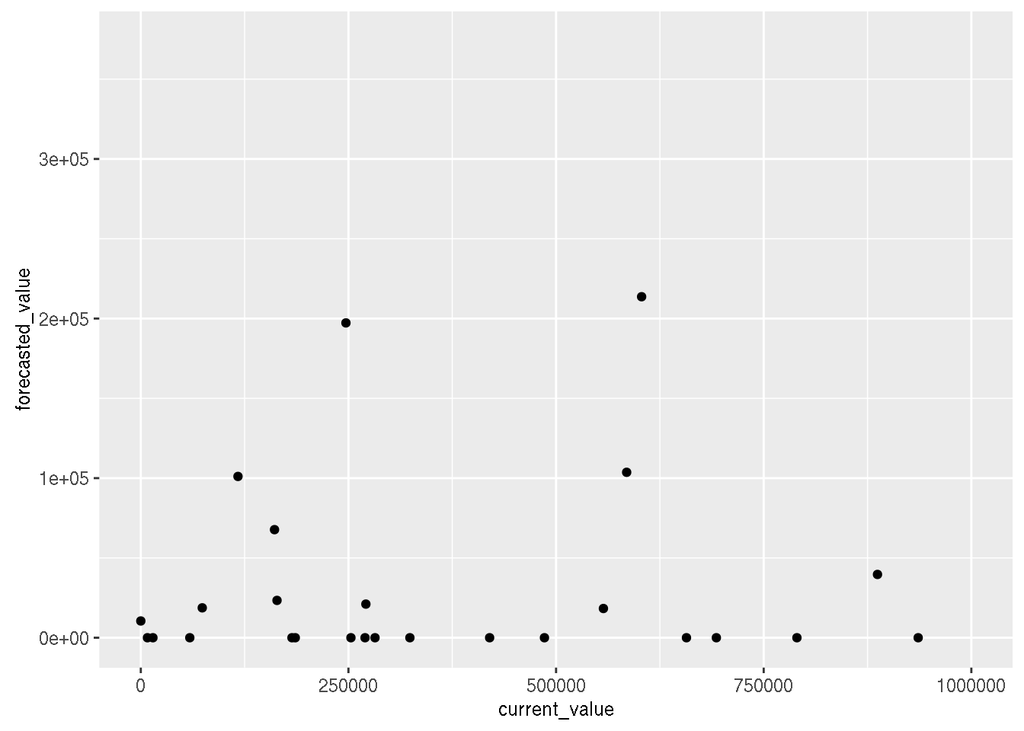

```r
library("ggplot2")
ggplot(data = permits, aes(x = current_value, y = forecasted_value)) +
  geom_point() +
  xlim(c(0,1e6))
```

So the first thing we do is call the `ggplot` function. This function lets R know that we’re creating a new plot, and any of the arguments we give the `ggplot` function are the *global* options for the plot: they apply to all layers on the plot.

We’ve passed in two arguments to `ggplot`. First, we tell `ggplot` what data we want to show on our figure, in this example the permits data we read in earlier. For the second argument we passed in the `aes` function, which tells `ggplot` how variables in the **data** map to *aesthetic* properties of the figure, in this case the **x** and **y** locations. Here we told `ggplot` we want to plot the “current_value” column of the permits data frame on the x-axis, and the “forecasted_value” column on the y-axis. Notice that we didn’t need to explicitly pass `aes` these columns (e.g. `x = permits[, "current_value"]`), this is because `ggplot` is smart enough to know to look in the **data** for that column!

By itself, the call to `ggplot` isn’t enough to draw a figure:

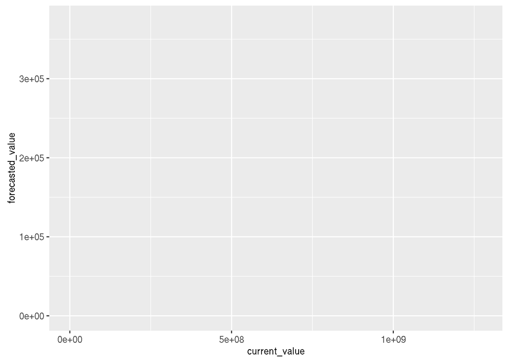

```r
ggplot(data = permits, aes(x = current_value, y = forecasted_value))
```

We need to tell `ggplot` how we want to visually represent the data, which we do by adding a new **geom** layer. In our example, we used `geom_point`, which tells `ggplot` we want to visually represent the relationship between **x** and **y** as a scatterplot of points:

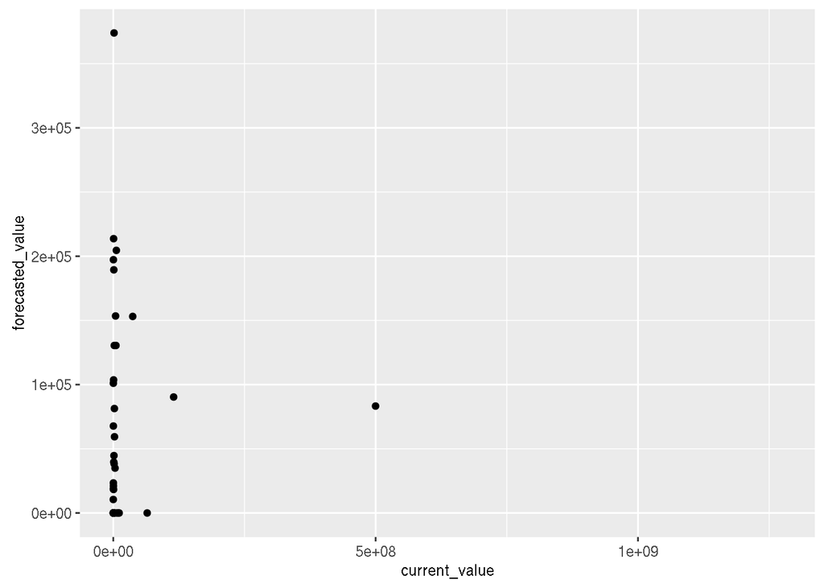

```r
ggplot(data = permits, aes(x = current_value, y = forecasted_value)) +
  geom_point()
```

Finally we limited the values on the x-axis `current_value` to just display values below 1 million.

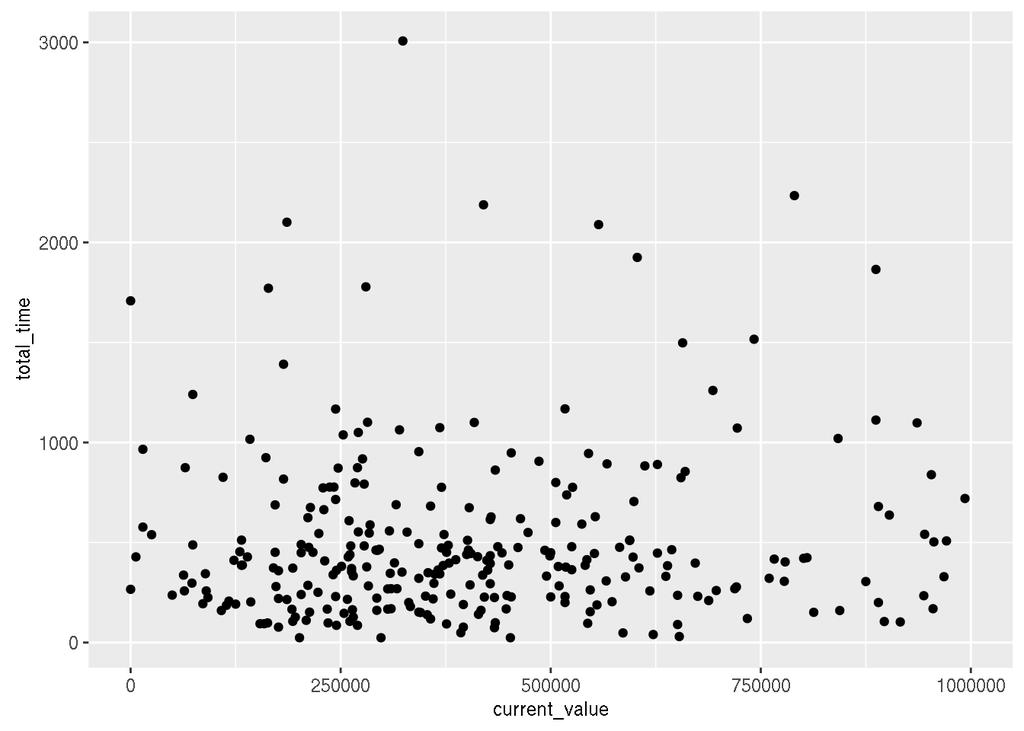

```r
ggplot(data = permits, aes(x = current_value, y = total_time)) +
  geom_point() +
  xlim(c(0,1e6))
```

## Challenge 1

> Modify the example so that the figure visualise how total_time has changed over time:

> ```r
> ggplot(data = permits, aes(x = current_value, y = total_time)) + geom_point()
> ```

> Hint: the permits dataset has a column called “isu_date”, which should appear on the x-axis.

## Challenge 2

> In the previous examples and challenge we’ve used the `aes` function to tell the scatterplot **geom** about the **x** and **y** locations of each point. Another *aesthetic* property we can modify is the point *color*. Modify the code from the previous challenge to **color** the points by the “city” column.

## Layers

Using a scatterplot probably isn’t the best for visualising change over time. Instead, let’s tell `ggplot` to visualise the data as a line plot:

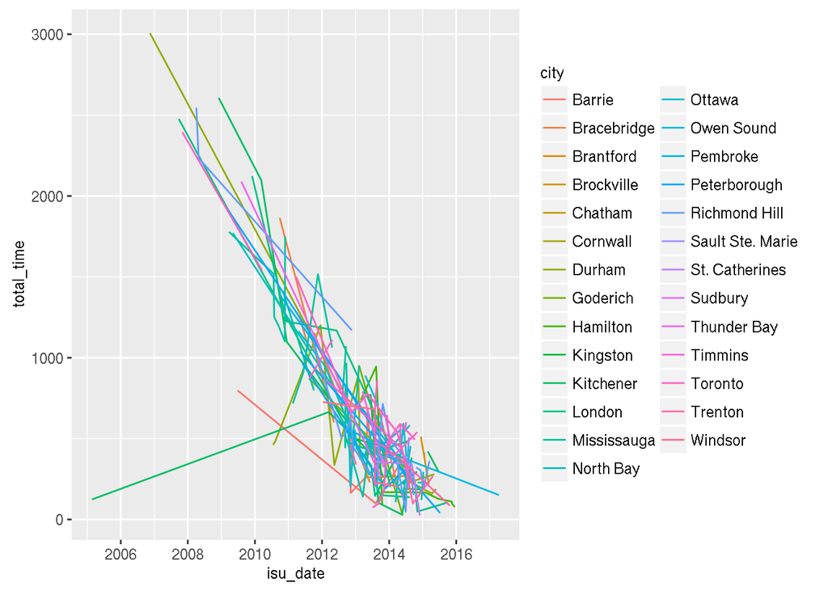

```r
ggplot(data = permits, aes(x=isu_date, y=total_time, color=city, by=mpac_wd)) +
  geom_line()
```

But what if we want to visualise both lines and points on the plot? We can simply add another layer to the plot:

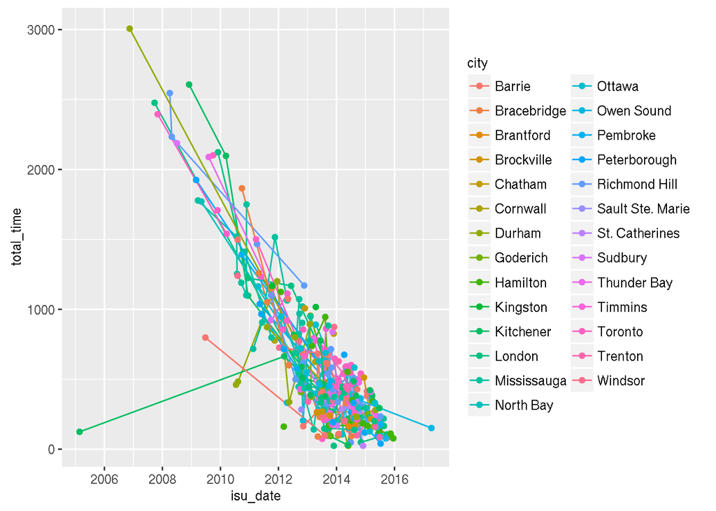

```r
ggplot(data = permits, aes(x=isu_date, y=total_time, by=mpac_wd, color=city)) +
  geom_line() + geom_point()
```

It’s important to note that each layer is drawn on top of the previous layer. In this example, the points have been drawn *on top of* the lines. Here’s a demonstration:

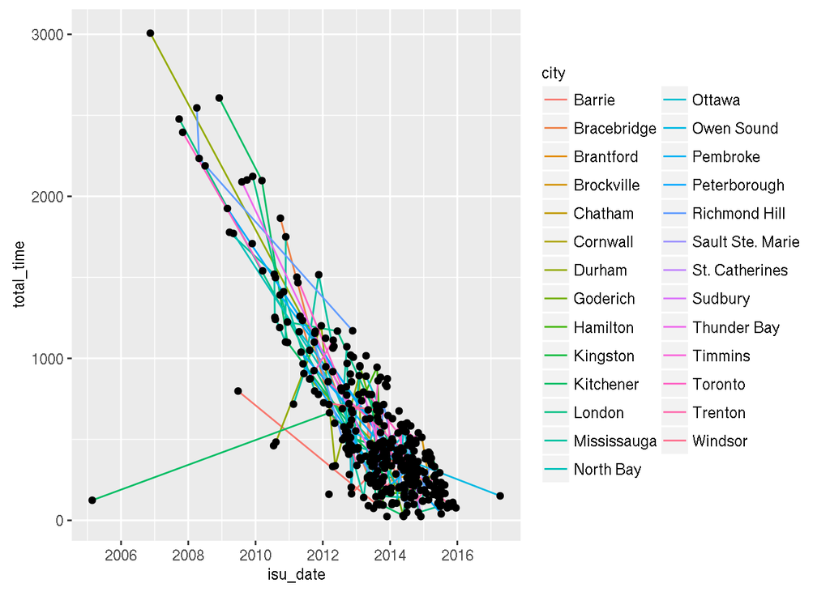

```r
ggplot(data = permits, aes(x=isu_date, y=total_time, by=mpac_wd)) +
  geom_line(aes(color=city)) + geom_point()
```

In this example, the *aesthetic* mapping of **color** has been moved from the global plot options in `ggplot` to the `geom_line` layer so it no longer applies to the points. Now we can clearly see that the points are drawn on top of the lines.

## Challenge 3

> Switch the order of the point and line layers from the previous example. What happened?

## Transformations and statistics

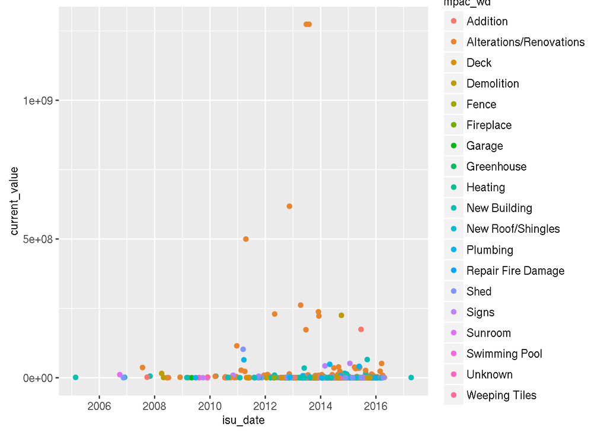

```r
ggplot(data = permits, aes(x = isu_date, y = current_value, color=mpac_wd)) +
  geom_point()
```

Currently it’s hard to see the relationship between the points due to some strong outliers in current_value. We can change the scale of units on the y axis using the *scale* functions. These control the mapping between the data values and visual values of an aesthetic. We can also modify the transparency of the points, using the *alpha* funtion, which is especially helpful when you have a large amount of data which is very clustered.

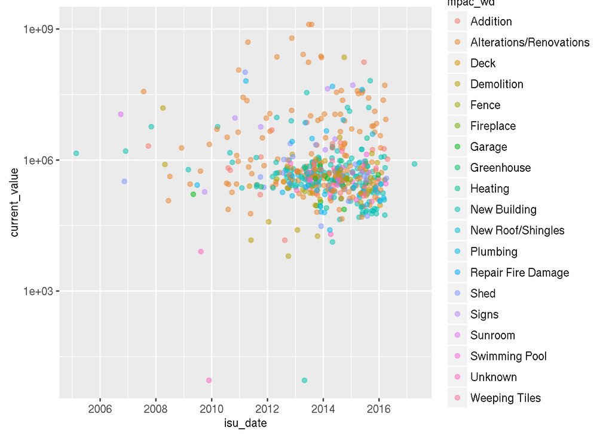

```r
ggplot(data = permits, aes(x = isu_date, y = current_value, color=mpac_wd)) +
  geom_point(alpha = 0.5) + scale_y_log10()
```

The `log10` function applied a transformation to the values of the current_value column before rendering them on the plot, so that each multiple of 10 now only corresponds to an increase in 1 on the transformed scale, e.g. a current value of 1,000 is now 3 on the y axis, a value of 10,000 corresponds to 4 on the y axis and so on. This makes it easier to visualise the spread of data on the y-axis.

We can fit a simple relationship to the data by adding another layer, `geom_smooth`:

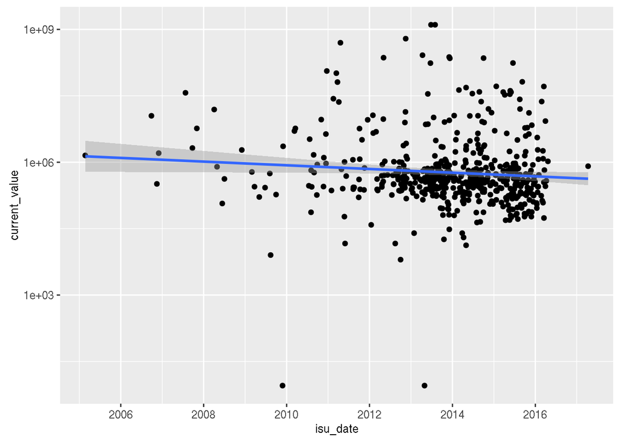

```r
ggplot(data = permits, aes(x = isu_date, y = current_value)) +
  geom_point() + scale_y_log10() + geom_smooth(method="lm")
```

We can make the line thicker by *setting* the **size** aesthetic in the `geom_smooth` layer:

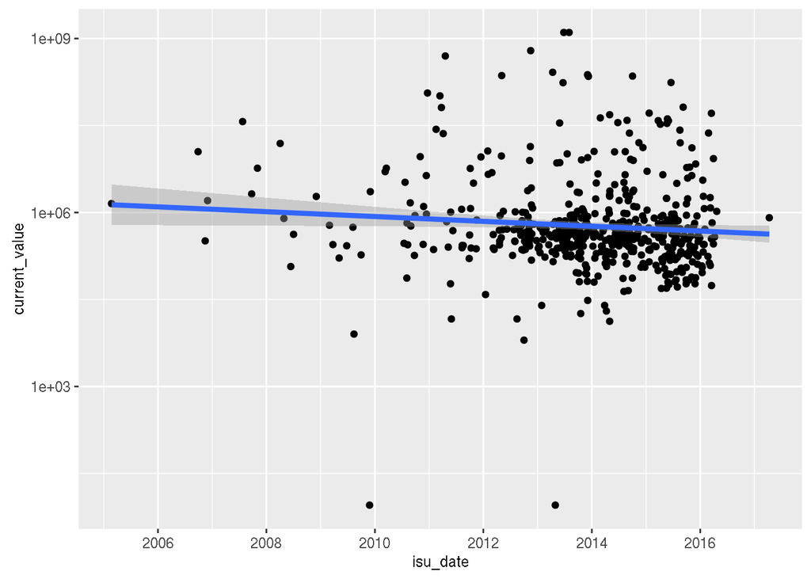

```r
ggplot(data = permits, aes(x = isu_date, y = current_value)) +
  geom_point() + scale_y_log10() + geom_smooth(method="lm", size=1.5)
```

There are two ways an *aesthetic* can be specified. Here we *set* the **size** aesthetic by passing it as an argument to `geom_smooth`. Previously in the lesson we’ve used the `aes` function to define a *mapping* between data variables and their visual representation.

## Challenge 4a

> Modify the color and size of the points on the point layer in the previous example.

> Hint: do not use the `aes` function.

## Challenge 4b

> Hint: The color argument can be used inside the aesthetic.

## Multi-panel figures

Earlier we visualised the change in current_value over time across all cities in one plot. Alternatively, we can split this out over multiple panels by adding a layer of **facet** panels. Focusing only on those cities with names that start with the letter “T” or “O”.

## Tip

> We start by subsetting the data. We use the `substr` function to pull out a part of a character string; in this case, the letters that occur in positions `start` through `stop`, inclusive, of the `permits$city` vector. The operator `%in%` allows us to make multiple comparisons rather than write out long subsetting conditions (in this case, `starts.with %in% c("T", "O")` is equivalent to `starts.with == "T" | starts.with == "O"`)

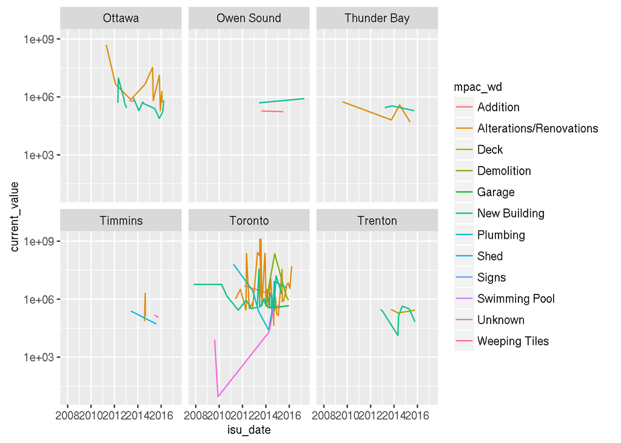

```r
starts.with <- substr(permits$city, start = 1, stop = 1)
to.cities <- permits[starts.with %in% c("T", "O"), ]
ggplot(data = to.cities, aes(x = isu_date, y = current_value, color=mpac_wd)) +
  geom_line() + facet_wrap( ~ city) + scale_y_log10()
```

## Modifying text

We can do this by adding a couple of different layers. The **theme** layer controls the axis text, and overall text size, and there are special layers for changing the axis labels. To change the legend title, we need to use the **scales** layer.

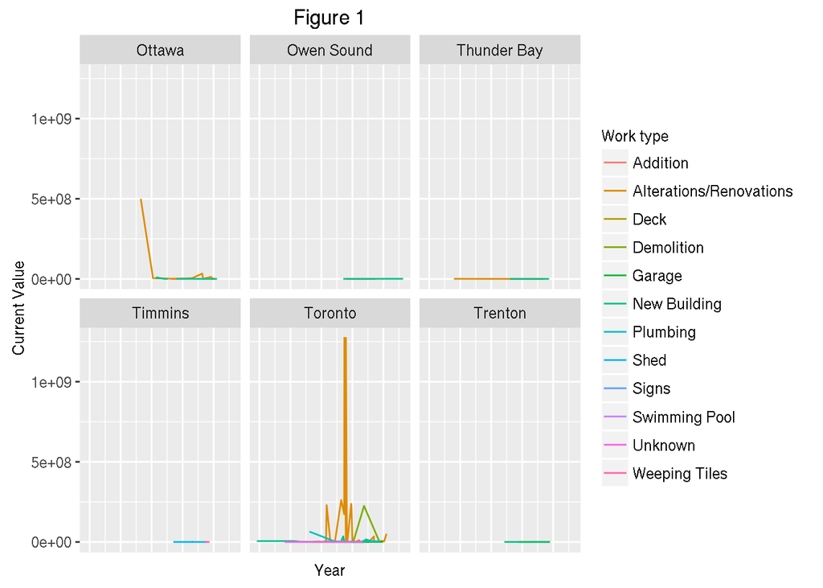

```r
ggplot(data = to.cities, aes(x = isu_date, y = current_value, color=mpac_wd)) +
  geom_line() + facet_wrap( ~ city) +
  xlab("Year") + ylab("Current Value") + ggtitle("Figure 1") +
  scale_colour_discrete(name="Work type") +
  theme(axis.text.x=element_blank(), axis.ticks.x=element_blank())
```

This is a taste of what you can do with `ggplot2`. RStudio provides a really useful [cheat sheet](http://www.rstudio.com/wp-content/uploads/2015/03/ggplot2-cheatsheet.pdf) of the different layers available, and more extensive documentation is available on the [ggplot2 website](http://docs.ggplot2.org/current/). Finally, if you have no idea how to change something, a quick google search will usually send you to a relevant question and answer on Stack Overflow with reusable code to modify!

## Challenge 5

> Create a density plot of current value, filled by work type.

## Solution to challenge 1

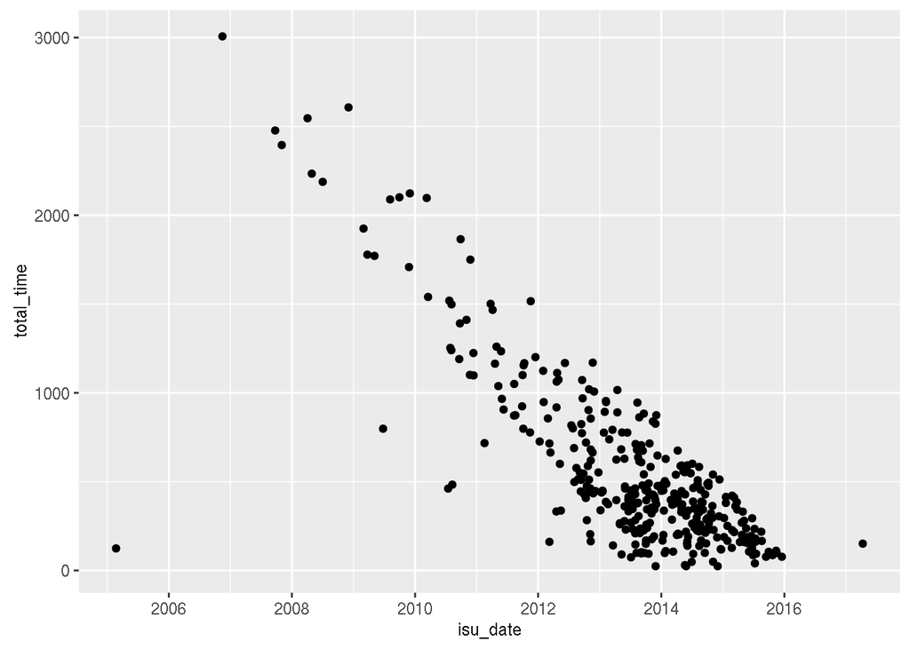

> ```r
> ggplot(data = permits, aes(x = isu_date, y = total_time)) + geom_point()
> ```

## Solution to challenge 2

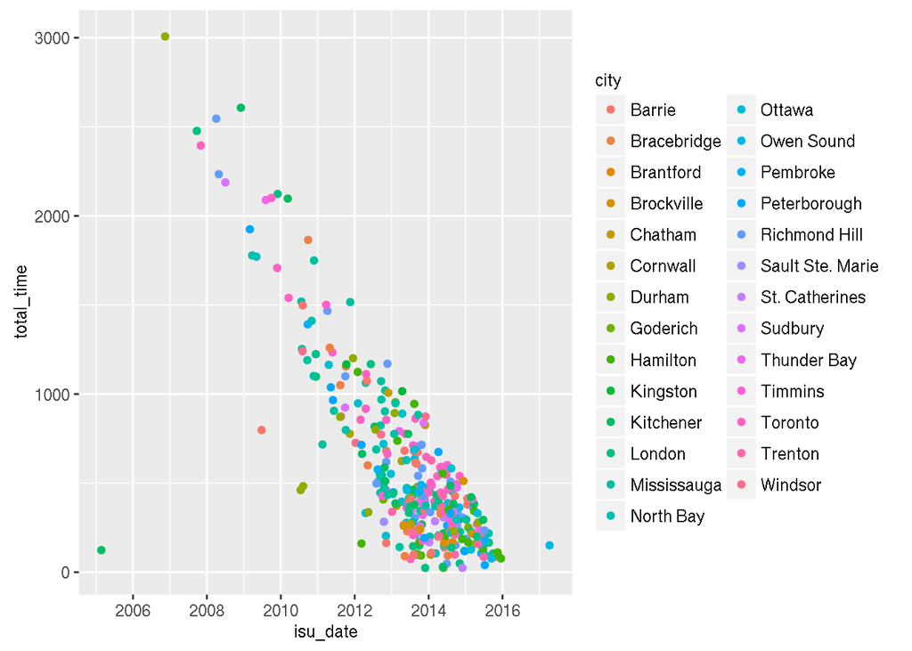

> ```r
> ggplot(data = permits, aes(x = isu_date, y = total_time, color=city)) +
>    geom_point()
> ```

## Solution to challenge 3

> Switch the order of the point and line layers from the previous example. What happened?

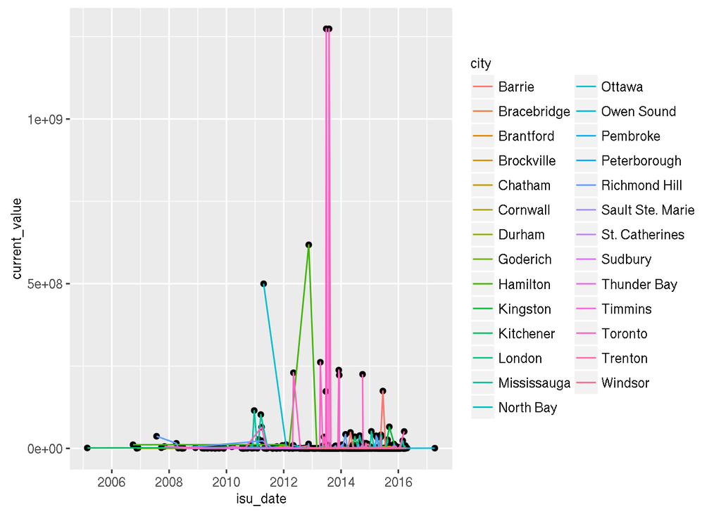

> ```r
> ggplot(data = permits, aes(x=isu_date, y=current_value, by=mpac_wd0)) +
>  geom_point() + geom_line(aes(color=city))
> ```

> The lines now get drawn over the points!

## Solution to challenge 4a

> Modify the color and size of the points on the point layer in the previous example.

> Hint: do not use the `aes` function.

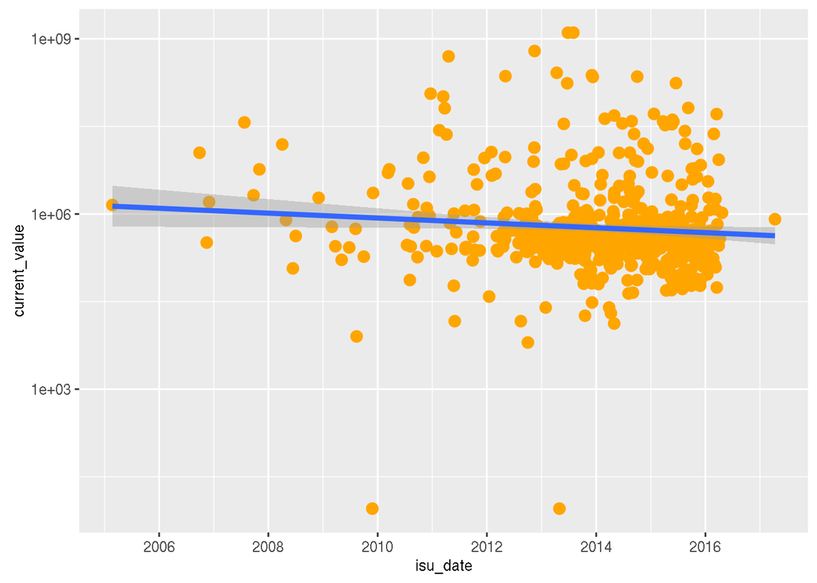

> ```r
> ggplot(data = permits, aes(x = isu_date, y = current_value)) +
>  geom_point(size=3, color="orange") + scale_y_log10() +
>  geom_smooth(method="lm", size=1.5)
> ```

## Solution to challenge 4b

> Hint: The color argument can be used inside the aesthetic.

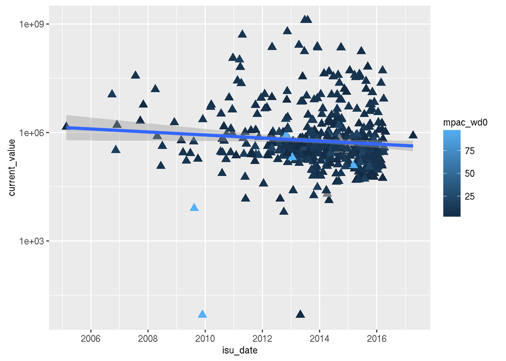

> ```r
> ggplot(data = permits, aes(x = isu_date, y = current_value, color = mpac_wd0)) +
> geom_point(size=3, pch=17) + scale_y_log10() +
> geom_smooth(method="lm", size=1.5)
> ```

## Solution to challenge 5

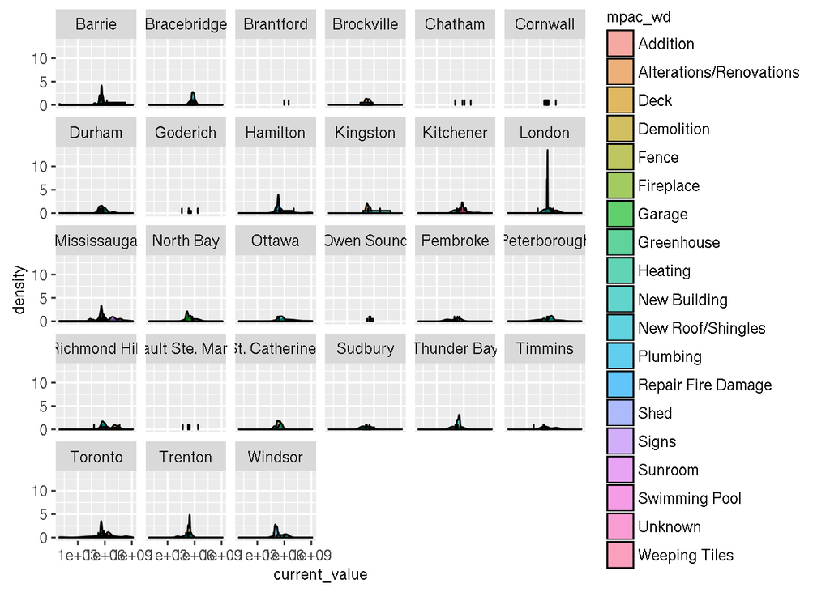

> ```r
> ggplot(data = permits, aes(x = current_value, fill=mpac_wd)) +
>  geom_density(alpha=0.6) + facet_wrap( ~ city) + scale_x_log10()
> ```